# Analisi dell'E-Commerce Brasiliano – Olist

## Analisi Retail e Clienti (2016–2018)

**Emilio Nahuel Pattini**  
Buenos Aires, Argentina  
1 febbraio 2026

## Indice dei Contenuti

- 1. Comprensione del Business e Domande
- 2. Caricamento e Panoramica dei Dati
  - 2.1 Caricamento dei Dati
  - 2.2 Panoramica dei Dati e Controlli Iniziali
- 3. Pulizia e Preparazione dei Dati
  - 3.1 Pulizia Iniziale dei Dati
  - 3.2 Feature Engineering e Trasformazioni di Business
- 4. Integrazione dei Dati e Primi Insight di Business
  - 4.1 Salvataggio dei Dati Puliti
  - 4.2 Primo Merge – Creazione di una Tabella Base di Lavoro
  - 4.3 Primo Insight di Business: Ricavi e Performance di Consegna per Stato
- 5. Analisi di Prodotti e Categorie
  - 5.1 Caricamento di Tabelle Aggiuntive
  - 5.2 Merge delle Informazioni sui Prodotti nella Tabella Base
  - 5.3 Visualizzazione e Insight sulle Performance per Categoria
  - 5.4 Performance per Categoria e Stato
  - 5.5 Visualizzazione: Partecipazione dei Ricavi per Categoria e Stato
- 6. Segmentazione Clienti – Analisi RFM
  - 6.1 Calcolo RFM
  - 6.2 Scoring RFM e Segmentazione Clienti
  - 6.3 Visualizzazione dei Segmenti RFM e Raccomandazioni Azionabili
  - 6.4 Esportazione dei Risultati RFM
- 7. Analisi di Cohorts – Retention dei Clienti nel Tempo
  - 7.1 Setup e Calcolo dei Cohorts
  - 7.2 Tabella e Heatmap di Retention
  - 7.3 Insight sui Cohorts e Raccomandazioni per la Retention
- 8. Previsione Base – Predizione dei Ricavi Futuri con Prophet
  - 8.1 Setup della Previsione con Prophet
  - 8.2 Insight di Previsione e Raccomandazioni di Business
- 9. Finalizzazione e Presentazione
  - 9.1 Esportazione delle Tabelle Chiave
  - 9.2 Riassunto del Progetto e Insight Chiave
  - 9.3 Dashboard in Power BI
  - 9.4 Conclusione del Progetto e Prossimi Passi
  - 9.5 Report Pubblicato e Download

## Introduzione

**Obiettivo del Progetto**  
Analisi orientata al business: vendite, comportamento del cliente, RFM, cohorts, CLV, previsione di base + raccomandazioni actionable.

**Dataset**  
Dataset Pubblico Olist – ~100k ordini (Kaggle)

**Tech Stack**

- Python: pandas, seaborn, plotly, matplotlib, prophet
- Dashboard: Power BI

## 1. Comprensione del Business e Domande

Domande chiave:

- Quali sono le categorie / prodotti top per ricavi?
- Retention e recurrenza dei clienti?
- Segmentazione RFM?
- Retention dei cohorts nel tempo?
- Performance di consegna per regione?
- Impatto dei metodi di pagamento?
- Opportunità di cross-sell?
- Previsione per le categorie top?

## 2. Caricamento e Panoramica dei Dati

Questa sezione copre l'ingestione iniziale dei file CSV raw dal dataset Olist e fornisce una panoramica di alto livello sulla struttura, dimensione e contenuto di ciascuna tabella. L'obiettivo è confermare il caricamento riuscito, identificare le relazioni chiave tra le tabelle e individuare eventuali segnali immediati di qualità dei dati prima di procedere con la pulizia e l'analisi.

### 2.1. Caricamento dei Dati

Carico le tabelle più rilevanti dal dataset Olist (orders, order_items, customers, payments, reviews) utilizzando pandas.  
In questa fase vengono caricate solo le tabelle essenziali per mantenere basso l'uso della memoria e concentrarsi sulle entità principali necessarie per l'analisi di vendite, clienti e logistica.

```python
# Imports
import pandas as pd
import matplotlib.pyplot as plt
import seaborn as sns
import plotly.express as px
import os
import plotly.graph_objects as go
from datetime import datetime
from prophet import Prophet
import plotly.io as pio

# set Plotly renderer so charts embed as interactive HTML instead of static images
pio.renderers.default = "notebook_connected"

# Settings for better visualizations
pd.set_option('display.max_columns', None)             # Show all columns
pd.set_option('display.max_rows', 100)                 # Show more rows
pd.set_option('display.float_format', '{:2f}'.format)  # Number formatting

sns.set_style("whitegrid")                             # Plot style
plt.rcParams['figure.figsize'] = (10, 6)               # Default figure size

print("Execution environment initialized successfully.")
print(f"• Pandas version: {pd.__version__}")
```

```
Execution environment initialized successfully.
• Pandas version: 2.3.3
```

```python
# Base path to the data folder
data_path = './data/'

# Load key tables
orders = pd.read_csv(data_path + 'raw/olist_orders_dataset.csv')
order_items = pd.read_csv(data_path + 'raw/olist_order_items_dataset.csv')
customers = pd.read_csv(data_path + 'raw/olist_customers_dataset.csv')
payments = pd.read_csv(data_path + 'raw/olist_order_payments_dataset.csv')
reviews = pd.read_csv(data_path + 'raw/olist_order_reviews_dataset.csv')
```

### 2.2. Panoramica dei Dati e Controlli Iniziali

Eseguo un'ispezione rapida di ciascuna tabella caricata per comprendere:

- Numero di righe e colonne
- Tipi di dati
- Presenza di valori mancanti
- Righe di esempio

Questo passo aiuta a mappare lo schema del dataset e decidere le priorità di pulizia successive.

```python
# Quick look at each one
def quick_overview(df, name):
    print(f"\n=== {name.upper()} ===")
    print(f"Rows: {df.shape[0]:,}")
    print(f"Columns: {df.shape[1]}")
    print("\nData types and missing values:")
    print(df.info(verbose=False))
    print("\nFirst three rows:")
    display(df.head(3))  # display works better than print in Jupyter

quick_overview(orders, "Orders")
quick_overview(order_items, "Order Items")
quick_overview(customers, "Customers")
quick_overview(payments, "Payments")
quick_overview(reviews, "Reviews")
```

```
=== ORDERS ===
Rows: 99,441
Columns: 8

Data types and missing values:
<class 'pandas.core.frame.DataFrame'>
RangeIndex: 99441 entries, 0 to 99440
Columns: 8 entries, order_id to order_estimated_delivery_date
dtypes: object(8)
memory usage: 6.1+ MB
None

First three rows:
```

|  | order_id | customer_id | order_status | order_purchase_timestamp | order_approved_at | order_delivered_carrier_date | order_delivered_customer_date | order_estimated_delivery_date |
| --- | --- | --- | --- | --- | --- | --- | --- | --- |
| 0 | e481f51cbdc54678b7cc49136f2d6af7 | 9ef432eb6251297304e76186b10a928d | delivered | 2017-10-02 10:56:33 | 2017-10-02 11:07:15 | 2017-10-04 19:55:00 | 2017-10-10 21:25:13 | 2017-10-18 00:00:00 |
| 1 | 53cdb2fc8bc7dce0b6741e2150273451 | b0830fb4747a6c6d20dea0b8c802d7ef | delivered | 2018-07-24 20:41:37 | 2018-07-26 03:24:27 | 2018-07-26 14:31:00 | 2018-08-07 15:27:45 | 2018-08-13 00:00:00 |
| 2 | 47770eb9100c2d0c44946d9cf07ec65d | 41ce2a54c0b03bf3443c3d931a367089 | delivered | 2018-08-08 08:38:49 | 2018-08-08 08:55:23 | 2018-08-08 13:50:00 | 2018-08-17 18:06:29 | 2018-09-04 00:00:00 |

```
=== ORDER ITEMS ===
Rows: 112,650
Columns: 7

Data types and missing values:
<class 'pandas.core.frame.DataFrame'>
RangeIndex: 112650 entries, 0 to 112649
Columns: 7 entries, order_id to freight_value
dtypes: float64(2), int64(1), object(4)
memory usage: 6.0+ MB
None

First three rows:
```

|  | order_id | order_item_id | product_id | seller_id | shipping_limit_date | price | freight_value |
| --- | --- | --- | --- | --- | --- | --- | --- |
| 0 | 00010242fe8c5a6d1ba2dd792cb16214 | 1 | 4244733e06e7ecb4970a6e2683c13e61 | 48436dade18ac8b2bce089ec2a041202 | 2017-09-19 09:45:35 | 58.900000 | 13.290000 |
| 1 | 00018f77f2f0320c557190d7a144bdd3 | 1 | e5f2d52b802189ee658865ca93d83a8f | dd7ddc04e1b6c2c614352b383efe2d36 | 2017-05-03 11:05:13 | 239.900000 | 19.930000 |
| 2 | 000229ec398224ef6ca0657da4fc703e | 1 | c777355d18b72b67abbeef9df44fd0fd | 5b51032eddd242adc84c38acab88f23d | 2018-01-18 14:48:30 | 199.000000 | 17.870000 |

```
=== CUSTOMERS ===
Rows: 99,441
Columns: 5

Data types and missing values:
<class 'pandas.core.frame.DataFrame'>
RangeIndex: 99441 entries, 0 to 99440
Columns: 5 entries, customer_id to customer_state
dtypes: int64(1), object(4)
memory usage: 3.8+ MB
None

First three rows:
```

|  | customer_id | customer_unique_id | customer_zip_code_prefix | customer_city | customer_state |
| --- | --- | --- | --- | --- | --- |
| 0 | 06b8999e2fba1a1fbc88172c00ba8bc7 | 861eff4711a542e4b93843c6dd7febb0 | 14409 | franca | SP |
| 1 | 18955e83d337fd6b2def6b18a428ac77 | 290c77bc529b7ac935b93aa66c333dc3 | 9790 | sao bernardo do campo | SP |
| 2 | 4e7b3e00288586ebd08712fdd0374a03 | 060e732b5b29e8181a18229c7b0b2b5e | 1151 | sao paulo | SP |

```
=== PAYMENTS ===
Rows: 103,886
Columns: 5

Data types and missing values:
<class 'pandas.core.frame.DataFrame'>
RangeIndex: 103886 entries, 0 to 103885
Columns: 5 entries, order_id to payment_value
dtypes: float64(1), int64(2), object(2)
memory usage: 4.0+ MB
None

First three rows:
```

|  | order_id | payment_sequential | payment_type | payment_installments | payment_value |
| --- | --- | --- | --- | --- | --- |
| 0 | b81ef226f3fe1789b1e8b2acac839d17 | 1 | credit_card | 8 | 99.330000 |
| 1 | a9810da82917af2d9aefd1278f1dcfa0 | 1 | credit_card | 1 | 24.390000 |
| 2 | 25e8ea4e93396b6fa0d3dd708e76c1bd | 1 | credit_card | 1 | 65.710000 |

```
=== REVIEWS ===
Rows: 99,224
Columns: 7

Data types and missing values:
<class 'pandas.core.frame.DataFrame'>
RangeIndex: 99224 entries, 0 to 99223
Columns: 7 entries, review_id to review_answer_timestamp
dtypes: int64(1), object(6)
memory usage: 5.3+ MB
None

First three rows:
```

|  | review_id | order_id | review_score | review_comment_title | review_comment_message | review_creation_date | review_answer_timestamp |
| --- | --- | --- | --- | --- | --- | --- | --- |
| 0 | 7bc2406110b926393aa56f80a40eba40 | 73fc7af87114b39712e6da79b0a377eb | 4 | NaN | NaN | 2018-01-18 00:00:00 | 2018-01-18 21:46:59 |
| 1 | 80e641a11e56f04c1ad469d5645fdfde | a548910a1c6147796b98fdf73dbeba33 | 5 | NaN | NaN | 2018-03-10 00:00:00 | 2018-03-11 03:05:13 |
| 2 | 228ce5500dc1d8e020d8d1322874b6f0 | f9e4b658b201a9f2ecdecbb34bed034b | 5 | NaN | NaN | 2018-02-17 00:00:00 | 2018-02-18 14:36:24 |

## 3. Pulizia e Preparazione dei Dati

### 3.1. Pulizia Iniziale dei Dati

In questa fase eseguo controlli fondamentali di qualità dei dati: conversione delle colonne timestamp in formato datetime appropriato, verifica dell'unicità degli identificatori chiave (order_id, customer_id), e ispezione dei valori mancanti nelle colonne critiche. L'obiettivo è garantire che i dati raw siano affidabili e pronti per l'analisi senza introdurre errori nei calcoli o nei join.

#### Conversioni di tipo

Converto le stringhe timestamp in oggetti datetime per poter eseguire calcoli basati sul tempo (delta, raggruppamenti per mese, ecc.) in modo accurato.

```python
# 3.1.1. Convert date columns to datetime

date_columns = [
    'order_purchase_timestamp',
    'order_approved_at',
    'order_delivered_carrier_date',
    'order_delivered_customer_date',
    'order_estimated_delivery_date'
]

for col in date_columns:
    orders[col] = pd.to_datetime(orders[col], errors='coerce')

print("Date columns converted:")
print(orders[date_columns].dtypes)
```

```
Date columns converted:
order_purchase_timestamp         datetime64[ns]
order_approved_at                datetime64[ns]
order_delivered_carrier_date     datetime64[ns]
order_delivered_customer_date    datetime64[ns]
order_estimated_delivery_date    datetime64[ns]
dtype: object
```

#### Controlli di Duplicati

Verifico che le chiavi primarie (order_id in orders, customer_id in customers) non abbiano duplicati, evitando conteggi gonfiati durante i merge o le aggregazioni.

```python
# 3.1.2. Check duplicates in key tables

print("\nDuplicates:")
print("orders order_id duplicated:", orders['order_id'].duplicated().sum())
print("customers customer_id duplicated:", customers['customer_id'].duplicated().sum())
print("order_items (should be 0):", order_items.duplicated().sum())
```

```
Duplicates:
orders order_id duplicated: 0
customers customer_id duplicated: 0
order_items (should be 0): 0
```

#### Ispezione dei Valori Mancanti

Identifico e comprendo i pattern di dati mancanti, in particolare nei timestamp relativi alle consegne e nei commenti delle recensioni, per decidere strategie di gestione appropriate.

```python
# 3.1.3. Missing values summary (focus on critical columns)

print("\nMissing values in orders:")
print(orders.isnull().sum()[orders.isnull().sum() > 0])

print("\nMissing values in reviews (expected high in comments):")
print(reviews.isnull().sum()[reviews.isnull().sum() > 0])
```

```
Missing values in orders:
order_approved_at                 160
order_delivered_carrier_date     1783
order_delivered_customer_date    2965
dtype: int64

Missing values in reviews (expected high in comments):
review_comment_title      87656
review_comment_message    58247
dtype: int64
```

### 3.2. Feature Engineering e Trasformazioni di Business

#### Flag di Stato

Creo colonne booleane (is_delivered, is_approved) per filtrare facilmente ordini completati ed evitare problemi con NaN in metriche basate sul tempo.

```python
# 3.2.1. Fill / handle missing timestamps in a business-friendly way

# Create flags (is_delivered, is_approved) for filtering later (e.g., only analyze delivered orders for delivery performance)
orders['is_delivered'] = orders['order_delivered_customer_date'].notna()
orders['is_approved'] = orders['order_approved_at'].notna()

print("Order status breakdown after cleaning:")
print(orders['order_status'].value_counts(normalize=True).round(3) * 100) # Use proportions (fractions that sum to 1), round to 3 d.p., and convert to %
```

```
Order status breakdown after cleaning:
order_status
delivered     97.000000
shipped        1.100000
canceled       0.600000
unavailable    0.600000
invoiced       0.300000
processing     0.300000
created        0.000000
approved       0.000000
Name: proportion, dtype: float64
```

#### Calcoli del Tempo di Consegna

Calcolo actual_delivery_time_days: i giorni di calendario reali dall'acquisto alla consegna al cliente — chiave per comprendere l'esperienza del cliente e la velocità logistica.

```python
# 3.2.2. Calculate actual delivery time (from purchase to delivered) | how long the customer actually waited (purchase → delivered)
orders['actual_delivery_time_days'] = (
    orders['order_delivered_customer_date'] - orders['order_purchase_timestamp']
).dt.days
```

```python
# 3.2.3. Calculate estimated vs actual delivery time difference | → positive = arrived late, negative = arrived early
orders['actual_minus_estimated_delivery_days'] = (
    orders['order_delivered_customer_date'] - orders['order_estimated_delivery_date']
).dt.days
```

#### Metriche di Ritardo e Performance

Calcolo actual_minus_estimated_delivery_days: quanto prima o dopo è arrivata l'ordine rispetto alla data promessa (negativo = anticipato, positivo = in ritardo) — essenziale per valutare l'accuratezza della promessa di consegna di Olist e il suo impatto sulla soddisfazione del cliente.

```python
# Filter extreme outliers

reasonable_delivery = orders['actual_delivery_time_days'].between(0, 60)  # realistic range
print("\n% of orders with reasonable delivery time (0–60 days):", reasonable_delivery.mean().round(3) * 100)
```

```
% of orders with reasonable delivery time (0–60 days): 96.7
```

```python
# Quick summary of new features

print("\nDelivery time stats (only delivered orders):")
delivered_orders = orders[orders['is_delivered']]             # Only consider delivered orders: Use mask 'orders['is_delivered']' to keep only rows where mask == True
print(delivered_orders[['actual_delivery_time_days', 'actual_minus_estimated_delivery_days']].describe())
```

```
Delivery time stats (only delivered orders):
       actual_delivery_time_days  actual_minus_estimated_delivery_days
count               96476.000000                          96476.000000
mean                   12.094086                            -11.876881
std                     9.551746                             10.183854
min                     0.000000                           -147.000000
25%                     6.000000                            -17.000000
50%                    10.000000                            -12.000000
75%                    15.000000                             -7.000000
max                   209.000000                            188.000000
```

## 4. Integrazione dei Dati e Primi Insight di Business

### 4.1. Salvataggio dei Dati Puliti

Salvo il DataFrame `orders` pulito e arricchito (con nuove feature) in una cartella di dati processati.

Questo segue le best practice: non sovrascrivere mai i dati raw e creare file intermedi riproducibili.

```python
# 4.1 Saving Cleaned Data

# Create 'processed' subfolder if it doesn't exist
processed_dir = './data/processed/'
os.makedirs(processed_dir, exist_ok=True)

# Save the enriched orders table
orders.to_csv(processed_dir + 'cleaned_orders_with_features.csv', index=False)

print("Cleaned & enriched orders saved to:")
print(processed_dir + 'cleaned_orders_with_features.csv')
```

```
Cleaned & enriched orders saved to:
./data/processed/cleaned_orders_with_features.csv
```

### 4.2. Primo Merge – Creazione di una Tabella Base di Lavoro

Combino le tabelle principali (orders + customers + payments) in un unico DataFrame master.

Questo fornisce una tabella unica con posizione del cliente, valore totale di pagamento e dettagli dell'ordine — ideale per analisi dei ricavi, segmentazione clienti e insight geografici.

```python
# 4.2 First Merge – Creating a Base Working Table

# Step 1: Aggregate payments per order (some orders have multiple payments)
# I want total payment value per order_id
payments_total = payments.groupby('order_id')['payment_value'].sum().reset_index()
payments_total = payments_total.rename(columns={'payment_value': 'total_order_value'})

# Step 2: Merge orders + customers (get state and unique customer id)
base_df = orders.merge(
    customers[['customer_id', 'customer_unique_id', 'customer_state', 'customer_city']],
    on='customer_id',
    how='left'
)

# Step 3: Add total payment value
base_df = base_df.merge(
    payments_total,
    on='order_id',
    how='left'
)

# Quality check after merge
print("Shape before merges:", orders.shape)
print("Shape after merges:", base_df.shape)
print("\nMissing total_order_value after merge:", base_df['total_order_value'].isnull().sum())

# Show first few rows of our new base table
print("\nFirst 3 rows of base working table:")
display(base_df[['order_id', 'customer_unique_id', 'customer_state', 'order_status',
                 'actual_delivery_time_days', 'total_order_value']].head(3))
```

```
Shape before merges: (99441, 12)
Shape after merges: (99441, 16)

Missing total_order_value after merge: 1

First 3 rows of base working table:
```

|  | order_id | customer_unique_id | customer_state | order_status | actual_delivery_time_days | total_order_value |
| --- | --- | --- | --- | --- | --- | --- |
| 0 | e481f51cbdc54678b7cc49136f2d6af7 | 7c396fd4830fd04220f754e42b4e5bff | SP | delivered | 8.000000 | 38.710000 |
| 1 | 53cdb2fc8bc7dce0b6741e2150273451 | af07308b275d755c9edb36a90c618231 | BA | delivered | 13.000000 | 141.460000 |
| 2 | 47770eb9100c2d0c44946d9cf07ec65d | 3a653a41f6f9fc3d2a113cf8398680e8 | GO | delivered | 9.000000 | 179.120000 |

### 4.3. Primo Insight di Business: Ricavi e Performance di Consegna per Stato

Aggrego la tabella base per calcolare il ricavo totale e il tempo medio di consegna per stato del cliente.

Questo fornisce una visione iniziale delle performance geografiche — identificando regioni ad alto valore e potenziali colli di bottiglia logistici.

```python
# 4.3 First Business Insight: Revenue & Delivery Performance by State

# Filter only delivered orders (to make delivery metrics meaningful)
delivered_base = base_df[base_df['is_delivered']]

# Aggregate key metrics by state
state_summary = delivered_base.groupby('customer_state').agg(
    total_revenue=('total_order_value', 'sum'),
    avg_delivery_days=('actual_delivery_time_days', 'mean'),
    median_delivery_days=('actual_delivery_time_days', 'median'),
    order_count=('order_id', 'count'),
    avg_delay_days=('actual_minus_estimated_delivery_days', 'mean')
).reset_index()

# Format numbers for readability
state_summary['total_revenue'] = state_summary['total_revenue'].round(2)
state_summary['avg_delivery_days'] = state_summary['avg_delivery_days'].round(1)
state_summary['median_delivery_days'] = state_summary['median_delivery_days'].round(1)
state_summary['avg_delay_days'] = state_summary['avg_delay_days'].round(1)

# Add the average revenue per order for each state
state_summary['avg_revenue_per_order'] = (state_summary['total_revenue'] / state_summary['order_count']).round(2)

# Sort by total revenue descending
state_summary = state_summary.sort_values('total_revenue', ascending=False)

# Show top 10 states
print("Top 10 states by total revenue (delivered orders only):")
display(
    state_summary.head(10).style.format({
        'total_revenue': '{:,.2f}',
        'avg_delivery_days': '{:.1f}',
        'median_delivery_days': '{:.1f}',
        'order_count': '{:,}',
        'avg_delay_days': '{:.1f}',
        'avg_revenue_per_order': '{:,.2f}',
    })
)
```

```
Top 10 states by total revenue (delivered orders only):
```

|  | customer_state | total_revenue | avg_delivery_days | median_delivery_days | order_count | avg_delay_days | avg_revenue_per_order |
| --- | --- | --- | --- | --- | --- | --- | --- |
| 25 | SP | 5,769,221.49 | 8.3 | 7.0 | 40,495 | -11.1 | 142.47 |
| 18 | RJ | 2,056,101.21 | 14.8 | 12.0 | 12,353 | -11.8 | 166.45 |
| 10 | MG | 1,819,321.70 | 11.5 | 10.0 | 11,355 | -13.2 | 160.22 |
| 22 | RS | 861,608.40 | 14.8 | 13.0 | 5,344 | -13.9 | 161.23 |
| 17 | PR | 781,919.55 | 11.5 | 10.0 | 4,923 | -13.3 | 158.83 |
| 23 | SC | 595,361.91 | 14.5 | 13.0 | 3,547 | -11.5 | 167.85 |
| 4 | BA | 591,270.60 | 18.9 | 16.0 | 3,256 | -10.8 | 181.59 |
| 6 | DF | 346,146.17 | 12.5 | 11.0 | 2,080 | -12.0 | 166.42 |
| 8 | GO | 334,294.22 | 15.2 | 13.0 | 1,957 | -12.2 | 170.82 |
| 7 | ES | 317,682.65 | 15.3 | 13.0 | 1,995 | -10.5 | 159.24 |

```python
# Interactive bar chart with Plotly

fig = px.bar(
    state_summary.head(10),
    x='customer_state',
    y='total_revenue',
    color='avg_delivery_days',
    color_continuous_scale='RdYlGn_r',   # Red = late, Green = early
    title='Top 10 States by Revenue (color = avg actual delivery days)',
    labels={
        'customer_state': 'State',
        'total_revenue': 'Total Revenue (BRL)',
        'avg_delivery_days': 'Avg Delivery Time (days)'
    },
    hover_data=['order_count', 'median_delivery_days', 'avg_delay_days']
)

fig.update_layout(
    xaxis_title="State (UF)",
    yaxis_title="Total Revenue (BRL)",
    coloraxis_colorbar_title="Avg Delivery (days)"
)

fig.show()
```

[interactive chart not shown]

#### Salvataggio del Riassunto per Stato

Esporto le metriche aggregate di performance per stato in un file processato per uso futuro (ad esempio, dashboarding in Power BI o visualizzazioni aggiuntive).

```python
# 4.3.1 Saving State-Level Summary

# Reuse the same processed directory I created earlier
processed_dir = './data/processed/'
os.makedirs(processed_dir, exist_ok=True)

# Save the summary
state_summary.to_csv(
    processed_dir + 'state_performance_summary.csv',
    index=False
)

print("State summary saved successfully to:")
print(processed_dir + 'state_performance_summary.csv')
```

```
State summary saved successfully to:
./data/processed/state_performance_summary.csv
```

## 5. Analisi di Prodotti e Categorie

### 5.1. Caricamento di Tabelle Aggiuntive

Carico le tabelle relative ai prodotti per abilitare insight a livello di categoria.

- `products`: attributi dei prodotti (categoria, dimensioni)
- `product_category_name_translation`: traduzione in inglese dei nomi delle categorie in portoghese
- `order_items`: collega ordini ai prodotti (quantità, prezzo, spedizione) e già caricata precedentemente.

```python
# 5.1 Loading Additional Tables

# Load the two new tables
products = pd.read_csv(data_path + 'raw/olist_products_dataset.csv')
category_translation = pd.read_csv(data_path + 'raw/product_category_name_translation.csv')

# Quick check
print("order_items shape:", order_items.shape)
print("products shape:", products.shape)
print("category_translation shape:", category_translation.shape)

# Preview both tables
quick_overview(products, "Products")
quick_overview(category_translation, "Category Translation")
```

```
order_items shape: (112650, 7)
products shape: (32951, 9)
category_translation shape: (71, 2)

=== PRODUCTS ===
Rows: 32,951
Columns: 9

Data types and missing values:
<class 'pandas.core.frame.DataFrame'>
RangeIndex: 32951 entries, 0 to 32950
Columns: 9 entries, product_id to product_width_cm
dtypes: float64(7), object(2)
memory usage: 2.3+ MB
None

First three rows:
```

|  | product_id | product_category_name | product_name_lenght | product_description_lenght | product_photos_qty | product_weight_g | product_length_cm | product_height_cm | product_width_cm |
| --- | --- | --- | --- | --- | --- | --- | --- | --- | --- |
| 0 | 1e9e8ef04dbcff4541ed26657ea517e5 | perfumaria | 40.000000 | 287.000000 | 1.000000 | 225.000000 | 16.000000 | 10.000000 | 14.000000 |
| 1 | 3aa071139cb16b67ca9e5dea641aaa2f | artes | 44.000000 | 276.000000 | 1.000000 | 1000.000000 | 30.000000 | 18.000000 | 20.000000 |
| 2 | 96bd76ec8810374ed1b65e291975717f | esporte_lazer | 46.000000 | 250.000000 | 1.000000 | 154.000000 | 18.000000 | 9.000000 | 15.000000 |

```
=== CATEGORY TRANSLATION ===
Rows: 71
Columns: 2

Data types and missing values:
<class 'pandas.core.frame.DataFrame'>
RangeIndex: 71 entries, 0 to 70
Columns: 2 entries, product_category_name to product_category_name_english
dtypes: object(2)
memory usage: 1.2+ KB
None

First three rows:
```

|  | product_category_name | product_category_name_english |
| --- | --- | --- |
| 0 | beleza_saude | health_beauty |
| 1 | informatica_acessorios | computers_accessories |
| 2 | automotivo | auto |

### 5.2. Merge delle Informazioni sui Prodotti nella Tabella Base

Unisco `order_items` con `products` e le traduzioni delle categorie, poi aggrego per ottenere metriche di performance per categoria (ricavi, conteggio ordini, prezzo medio, ecc.).

```python
# 5.2 Merging Product Information

# Step 1: Translate category names (left join to keep all products)
products_en = products.merge(
    category_translation,
    on='product_category_name',
    how='left'
)

# Step 2: Merge order_items with products_en (add category, price, etc.)
items_with_category = order_items.merge(
    products_en[['product_id', 'product_category_name_english', 'product_weight_g']],
    on='product_id',
    how='left'
)

# Handle missing English category names
items_with_category['product_category_name_english'] = items_with_category['product_category_name_english'].fillna('uncategorized')

# Quick check for missing English names (should be very few)
print("Missing English category names:",
      items_with_category['product_category_name_english'].isnull().sum())

# Step 3: Aggregate by category (revenue, count, avg price, etc.)
category_performance = items_with_category.groupby('product_category_name_english').agg(
    total_revenue=('price', 'sum'),
    total_freight=('freight_value', 'sum'),
    order_items_count=('order_id', 'count'),
    unique_orders=('order_id', 'nunique'),
    avg_price=('price', 'mean'),
    avg_weight_g=('product_weight_g', 'mean')
).reset_index()

# Add revenue share %
total_revenue_all = category_performance['total_revenue'].sum()
category_performance['revenue_share_pct'] = (
    category_performance['total_revenue'] / total_revenue_all * 100
).round(2)

# Sort by revenue descending
category_performance = category_performance.sort_values('total_revenue', ascending=False)

# Show top 15 categories
print("\nTop 15 categories by total revenue:")
display(
    category_performance.head(15).style.format({
        'total_revenue': '{:,.2f}',
        'total_freight': '{:,.2f}',
        'avg_price': '{:,.2f}',
        'avg_weight_g': '{:.0f}',
        'revenue_share_pct': '{:.2f}%'
    })
)
```

```
Missing English category names: 0

Top 15 categories by total revenue:
```

|  | product_category_name_english | total_revenue | total_freight | order_items_count | unique_orders | avg_price | avg_weight_g | revenue_share_pct |
| --- | --- | --- | --- | --- | --- | --- | --- | --- |
| 43 | health_beauty | 1,258,681.34 | 182,566.73 | 9670 | 8836 | 130.16 | 1049 | 9.26% |
| 71 | watches_gifts | 1,205,005.68 | 100,535.93 | 5991 | 5624 | 201.14 | 581 | 8.87% |
| 7 | bed_bath_table | 1,036,988.68 | 204,693.04 | 11115 | 9417 | 93.30 | 2117 | 7.63% |
| 65 | sports_leisure | 988,048.97 | 168,607.51 | 8641 | 7720 | 114.34 | 1743 | 7.27% |
| 15 | computers_accessories | 911,954.32 | 147,318.08 | 7827 | 6689 | 116.51 | 903 | 6.71% |
| 39 | furniture_decor | 729,762.49 | 172,749.30 | 8334 | 6449 | 87.56 | 2653 | 5.37% |
| 20 | cool_stuff | 635,290.85 | 84,039.10 | 3796 | 3632 | 167.36 | 2549 | 4.67% |
| 49 | housewares | 632,248.66 | 146,149.11 | 6964 | 5884 | 90.79 | 3215 | 4.65% |
| 5 | auto | 592,720.11 | 92,664.21 | 4235 | 3897 | 139.96 | 2594 | 4.36% |
| 42 | garden_tools | 485,256.46 | 98,962.75 | 4347 | 3518 | 111.63 | 2824 | 3.57% |
| 69 | toys | 483,946.60 | 77,425.95 | 4117 | 3886 | 117.55 | 1857 | 3.56% |
| 6 | baby | 411,764.89 | 68,353.11 | 3065 | 2885 | 134.34 | 3273 | 3.03% |
| 59 | perfumery | 399,124.87 | 54,213.84 | 3419 | 3162 | 116.74 | 480 | 2.94% |
| 68 | telephony | 323,667.53 | 71,215.79 | 4545 | 4199 | 71.21 | 262 | 2.38% |
| 57 | office_furniture | 273,960.70 | 68,571.95 | 1691 | 1273 | 162.01 | 11390 | 2.02% |

### 5.3. Visualizzazione della Performance per Categoria e Insight

Visualizzo le categorie top per ricavi e genero insight actionable su pricing, spedizione e opportunità.

```python
# Top 10 categories for clean visualization
top_categories = category_performance.head(10)

# Bar chart: Revenue by category
fig_bar = px.bar(
    top_categories,
    x='product_category_name_english',
    y='total_revenue',
    color='avg_price',
    color_continuous_scale='YlOrRd',
    title='Top 10 Product Categories by Total Revenue',
    labels={
        'product_category_name_english': 'Category',
        'total_revenue': 'Total Revenue (BRL)',
        'avg_price': 'Average Unit Price (BRL)'
    },
    hover_data=['order_items_count', 'unique_orders', 'total_freight', 'revenue_share_pct']
)

fig_bar.update_layout(
    xaxis_title="Category",
    yaxis_title="Total Revenue (BRL)",
    xaxis_tickangle=-45,
    coloraxis_colorbar_title="Avg Price"
)

fig_bar.show()
```

[interactive chart not shown]

```python
# Pie chart: Revenue share (top 10 + others)
others_revenue = category_performance.iloc[10:]['total_revenue'].sum()

pie_data = pd.concat([
    top_categories[['product_category_name_english', 'total_revenue']],
    pd.DataFrame({'product_category_name_english': ['Others'], 'total_revenue': [others_revenue]})
])

fig_pie = px.pie(
    pie_data,
    values='total_revenue',
    names='product_category_name_english',
    title='Revenue Share - Top 10 Categories vs Others',
    hole=0.4  # donut style
)

fig_pie.show()
```

[interactive chart not shown]

### 5.4. Performance per Categoria e Stato

Riunisco le informazioni sulle categorie con la tabella base dei clienti per analizzare quali categorie di prodotti performano meglio in ciascun stato brasiliano.

Questo aiuta a identificare preferenze regionali, opportunità localizzate e potenziali aggiustamenti logistici/pricing per regione.

```python
# 5.4 Category Performance by State

# Step 1: Keep only delivered orders for meaningful metrics
delivered_base = base_df[base_df['is_delivered']].copy()

# Step 2: Add category info to delivered orders
# First, aggregate items by order_id (one row per order with main category)
# For simplicity, I take the category of the most expensive item per order (common approach)
order_main_category = (
    items_with_category.loc[
        items_with_category.groupby('order_id')['price'].idxmax()
    ]
    [['order_id', 'product_category_name_english']]
    .reset_index(drop=True)
)

# Merge main category into delivered_base
delivered_with_category = delivered_base.merge(
    order_main_category,
    on='order_id',
    how='left'
)

# Fill any missing categories (rare after previous fix)
delivered_with_category['product_category_name_english'] = delivered_with_category['product_category_name_english'].fillna('uncategorized')

# Step 3: Aggregate: revenue & order count per state + category
state_category_summary = delivered_with_category.groupby(
    ['customer_state', 'product_category_name_english']
).agg(
    total_revenue=('total_order_value', 'sum'),
    order_count=('order_id', 'nunique'),
    avg_ticket=('total_order_value', 'mean')
).reset_index()

# Add revenue share within each state
state_category_summary['state_total_revenue'] = state_category_summary.groupby('customer_state')['total_revenue'].transform('sum')
state_category_summary['revenue_share_in_state_pct'] = (
    state_category_summary['total_revenue'] / state_category_summary['state_total_revenue'] * 100
).round(2)

# Sort by state and then by revenue descending within state
state_category_summary = state_category_summary.sort_values(
    ['customer_state', 'total_revenue'], ascending=[True, False]
)

# Show top categories for the top 5 revenue states (SP, RJ, MG, RS, PR)
top_states = ['SP', 'RJ', 'MG', 'RS', 'PR']
for state in top_states:
    print(f"\nTop 10 categories in {state} by revenue:")
    display(
        state_category_summary[state_category_summary['customer_state'] == state]
        .head(10)
        .style.format({
            'total_revenue': '{:,.2f}',
            'avg_ticket': '{:,.2f}',
            'revenue_share_in_state_pct': '{:.2f}%',
            'state_total_revenue': '{:.2f}'
        })
    )
```

```
Top 10 categories in SP by revenue:
```

|  | customer_state | product_category_name_english | total_revenue | order_count | avg_ticket | state_total_revenue | revenue_share_in_state_pct |
| --- | --- | --- | --- | --- | --- | --- | --- |
| 1272 | SP | bed_bath_table | 549,408.91 | 4307 | 127.56 | 5769221.49 | 9.52% |
| 1308 | SP | health_beauty | 509,859.18 | 3693 | 138.10 | 5769221.49 | 8.84% |
| 1335 | SP | watches_gifts | 449,135.06 | 2083 | 215.62 | 5769221.49 | 7.79% |
| 1329 | SP | sports_leisure | 427,734.06 | 3203 | 133.54 | 5769221.49 | 7.41% |
| 1280 | SP | computers_accessories | 386,706.97 | 2609 | 148.22 | 5769221.49 | 6.70% |
| 1304 | SP | furniture_decor | 331,287.25 | 2618 | 126.54 | 5769221.49 | 5.74% |
| 1314 | SP | housewares | 323,729.96 | 2693 | 120.21 | 5769221.49 | 5.61% |
| 1270 | SP | auto | 235,440.59 | 1579 | 149.11 | 5769221.49 | 4.08% |
| 1285 | SP | cool_stuff | 230,410.92 | 1279 | 180.15 | 5769221.49 | 3.99% |
| 1333 | SP | toys | 205,513.18 | 1568 | 131.07 | 5769221.49 | 3.56% |

```
Top 10 categories in RJ by revenue:
```

|  | customer_state | product_category_name_english | total_revenue | order_count | avg_ticket | state_total_revenue | revenue_share_in_state_pct |
| --- | --- | --- | --- | --- | --- | --- | --- |
| 986 | RJ | watches_gifts | 188,485.58 | 784 | 240.42 | 2056101.21 | 9.17% |
| 924 | RJ | bed_bath_table | 175,594.31 | 1342 | 130.85 | 2056101.21 | 8.54% |
| 960 | RJ | health_beauty | 159,174.66 | 935 | 170.24 | 2056101.21 | 7.74% |
| 980 | RJ | sports_leisure | 140,578.56 | 889 | 158.13 | 2056101.21 | 6.84% |
| 932 | RJ | computers_accessories | 138,232.02 | 832 | 166.14 | 2056101.21 | 6.72% |
| 956 | RJ | furniture_decor | 118,425.00 | 809 | 146.38 | 2056101.21 | 5.76% |
| 966 | RJ | housewares | 93,000.20 | 709 | 131.17 | 2056101.21 | 4.52% |
| 937 | RJ | cool_stuff | 91,488.42 | 478 | 191.40 | 2056101.21 | 4.45% |
| 959 | RJ | garden_tools | 85,899.27 | 522 | 164.56 | 2056101.21 | 4.18% |
| 984 | RJ | toys | 83,263.44 | 539 | 154.48 | 2056101.21 | 4.05% |

```
Top 10 categories in MG by revenue:
```

|  | customer_state | product_category_name_english | total_revenue | order_count | avg_ticket | state_total_revenue | revenue_share_in_state_pct |
| --- | --- | --- | --- | --- | --- | --- | --- |
| 514 | MG | health_beauty | 175,305.23 | 987 | 177.61 | 1819321.70 | 9.64% |
| 480 | MG | bed_bath_table | 155,527.65 | 1108 | 140.37 | 1819321.70 | 8.55% |
| 541 | MG | watches_gifts | 132,117.43 | 598 | 220.93 | 1819321.70 | 7.26% |
| 535 | MG | sports_leisure | 130,027.02 | 845 | 153.88 | 1819321.70 | 7.15% |
| 487 | MG | computers_accessories | 126,693.85 | 857 | 147.83 | 1819321.70 | 6.96% |
| 510 | MG | furniture_decor | 97,409.77 | 701 | 138.96 | 1819321.70 | 5.35% |
| 520 | MG | housewares | 92,826.66 | 676 | 137.32 | 1819321.70 | 5.10% |
| 478 | MG | auto | 82,521.85 | 458 | 180.18 | 1819321.70 | 4.54% |
| 492 | MG | cool_stuff | 79,890.81 | 422 | 189.31 | 1819321.70 | 4.39% |
| 513 | MG | garden_tools | 72,488.16 | 478 | 151.65 | 1819321.70 | 3.98% |

```
Top 10 categories in RS by revenue:
```

|  | customer_state | product_category_name_english | total_revenue | order_count | avg_ticket | state_total_revenue | revenue_share_in_state_pct |
| --- | --- | --- | --- | --- | --- | --- | --- |
| 1098 | RS | bed_bath_table | 73,416.22 | 532 | 138.00 | 861608.40 | 8.52% |
| 1127 | RS | furniture_decor | 65,638.11 | 425 | 154.44 | 861608.40 | 7.62% |
| 1106 | RS | computers_accessories | 61,275.72 | 385 | 159.16 | 861608.40 | 7.11% |
| 1151 | RS | sports_leisure | 60,578.49 | 411 | 147.39 | 861608.40 | 7.03% |
| 1130 | RS | health_beauty | 59,453.00 | 388 | 153.23 | 861608.40 | 6.90% |
| 1157 | RS | watches_gifts | 51,874.17 | 222 | 233.67 | 861608.40 | 6.02% |
| 1111 | RS | cool_stuff | 49,747.79 | 251 | 198.20 | 861608.40 | 5.77% |
| 1136 | RS | housewares | 48,260.70 | 340 | 141.94 | 861608.40 | 5.60% |
| 1129 | RS | garden_tools | 38,871.63 | 219 | 177.50 | 861608.40 | 4.51% |
| 1155 | RS | toys | 33,347.80 | 200 | 166.74 | 861608.40 | 3.87% |

```
Top 10 categories in PR by revenue:
```

|  | customer_state | product_category_name_english | total_revenue | order_count | avg_ticket | state_total_revenue | revenue_share_in_state_pct |
| --- | --- | --- | --- | --- | --- | --- | --- |
| 911 | PR | sports_leisure | 66,731.65 | 419 | 159.26 | 781919.55 | 8.53% |
| 917 | PR | watches_gifts | 62,263.22 | 265 | 234.96 | 781919.55 | 7.96% |
| 891 | PR | health_beauty | 61,366.50 | 375 | 163.64 | 781919.55 | 7.85% |
| 888 | PR | furniture_decor | 60,326.83 | 382 | 157.92 | 781919.55 | 7.72% |
| 859 | PR | bed_bath_table | 55,499.30 | 395 | 140.50 | 781919.55 | 7.10% |
| 866 | PR | computers_accessories | 50,583.03 | 333 | 151.90 | 781919.55 | 6.47% |
| 871 | PR | cool_stuff | 41,963.34 | 201 | 208.77 | 781919.55 | 5.37% |
| 897 | PR | housewares | 38,546.88 | 279 | 138.16 | 781919.55 | 4.93% |
| 857 | PR | auto | 32,421.59 | 202 | 160.50 | 781919.55 | 4.15% |
| 915 | PR | toys | 27,313.06 | 198 | 137.94 | 781919.55 | 3.49% |

### 5.5. Visualizzazione: Partecipazione dei Ricavi per Categoria e Stato

Un heatmap mostra l'importanza relativa di ciascuna categoria all'interno degli stati principali, evidenziando preferenze regionali.

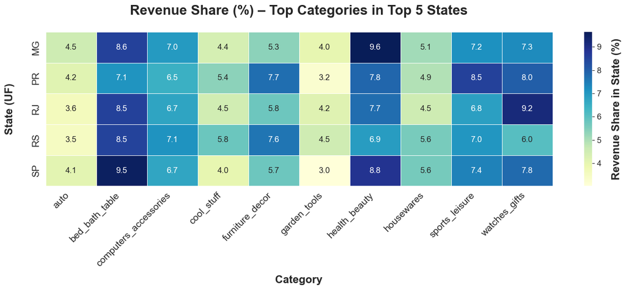

```python
# 5.4.1 Visualization: Heatmap of Revenue Share by State and Category

# Filter to top 5 states and top 10 categories for readability
top_states = ['SP', 'RJ', 'MG', 'RS', 'PR']
top_cats = category_performance.head(10)['product_category_name_english'].tolist()

heatmap_df = state_category_summary[
    (state_category_summary['customer_state'].isin(top_states)) &
    (state_category_summary['product_category_name_english'].isin(top_cats))
]

# Pivot: states as rows, categories as columns, revenue share as values
pivot_table = heatmap_df.pivot(
    index='customer_state',      # rows
    columns='product_category_name_english',
    values='revenue_share_in_state_pct'
).fillna(0)

# Plot heatmap
plt.figure(figsize=(14, 6))

hm = sns.heatmap(
        pivot_table,
        annot=True,                # show numbers in cells
        fmt=".1f",
        annot_kws={"size": 12},    # font size of the numbers inside cells
        cmap="YlGnBu",
        linewidths=0.5,
        cbar_kws={'label': 'Revenue Share in State (%)'}
)

# Style the colorbar label
cbar = hm.collections[0].colorbar
cbar.set_label(
    'Revenue Share in State (%)',
    fontsize=16,               # ← adjust this number (16 is noticeably larger)
    fontweight='bold',
    labelpad=15
)
cbar.ax.tick_params(labelsize=12) # larger ticks on colorbar

plt.title('Revenue Share (%) – Top Categories in Top 5 States', fontsize=20, fontweight='bold', pad=25)
plt.xlabel('Category', fontsize=16, fontweight='bold', labelpad=10)
plt.ylabel('State (UF)', fontsize=16, fontweight='bold', labelpad=25)
plt.xticks(rotation=45, ha='right', fontsize=14)
plt.yticks(fontsize=14)
plt.tight_layout()
plt.show()
```

## 6. Segmentazione Clienti – Analisi RFM

### 6.1. Calcolo RFM

Calcolo le metriche classiche RFM per ciascun cliente unico:

- **Recency**: Giorni dall'ultimo acquisto (minore = più recente)
- **Frequency**: Numero di ordini effettuati
- **Monetary**: Ricavo totale generato dal cliente

Questo costituisce la base per segmentare i clienti in gruppi (es. VIP, a rischio, nuovi, persi) e derivare strategie di retention e upselling.

```python
# 6.1 RFM Calculation

# Use only delivered orders for accurate purchase behavior
rfm_base = base_df[base_df['is_delivered']].copy()

# Current reference date (use the max purchase date + 1 day for realism)
reference_date = rfm_base['order_purchase_timestamp'].max() + pd.Timedelta(days=1)

# Aggregate per customer_unique_id
rfm = rfm_base.groupby('customer_unique_id').agg(
    recency=('order_purchase_timestamp', lambda x: (reference_date - x.max()).days), # Days since last purchase (lower number = more recent/active customer)
    frequency=('order_id', 'nunique'), # Number of distinct orders (higher = more loyal/repeat buyer)
    monetary=('total_order_value', 'sum') # Total BRL spent (higher = higher lifetime value)
).reset_index()

# Quick overview
print("RFM table shape:", rfm.shape)
print("\nRFM descriptive stats:")
print(rfm[['recency', 'frequency', 'monetary']].describe().round(2))

# Show top 10 customers by monetary value (VIP preview)
print("\nTop 10 customers by total spend:")
display(rfm.sort_values('monetary', ascending=False).head(10).style.format({
    'monetary': '{:,.2f}',
    'recency': '{:,}'
}))
```

```
RFM table shape: (93356, 4)

RFM descriptive stats:
           recency    frequency     monetary
count 93356.000000 93356.000000 93356.000000
mean    237.970000     1.030000   165.190000
std     152.620000     0.210000   226.320000
min       1.000000     1.000000     0.000000
25%     114.000000     1.000000    63.050000
50%     219.000000     1.000000   107.780000
75%     346.000000     1.000000   182.540000
max     714.000000    15.000000 13664.080000

Top 10 customers by total spend:
```

|  | customer_unique_id | recency | frequency | monetary |
| --- | --- | --- | --- | --- |
| 3724 | 0a0a92112bd4c708ca5fde585afaa872 | 334 | 1 | 13,664.08 |
| 79634 | da122df9eeddfedc1dc1f5349a1a690c | 515 | 2 | 7,571.63 |
| 43166 | 763c8b1c9c68a0229c42c9fc6f662b93 | 46 | 1 | 7,274.88 |
| 80461 | dc4802a71eae9be1dd28f5d788ceb526 | 563 | 1 | 6,929.31 |
| 25432 | 459bef486812aa25204be022145caa62 | 35 | 1 | 6,922.21 |
| 93079 | ff4159b92c40ebe40454e3e6a7c35ed6 | 462 | 1 | 6,726.66 |
| 23407 | 4007669dec559734d6f53e029e360987 | 279 | 1 | 6,081.54 |
| 87145 | eebb5dda148d3893cdaf5b5ca3040ccb | 498 | 1 | 4,764.34 |
| 26636 | 48e1ac109decbb87765a3eade6854098 | 69 | 1 | 4,681.78 |
| 73126 | c8460e4251689ba205045f3ea17884a1 | 22 | 4 | 4,655.91 |

### 6.2. Scoring RFM e Segmentazione Clienti

Assegno punteggi (4 = migliore, 1 = peggiore) a Recency (minore = migliore), Frequency e Monetary.

- Recency e Monetary usano scoring basato sui quartili (`pd.qcut`)
- Frequency usa soglie personalizzate a causa dell'estrema skewness (97 % dei clienti acquista solo una volta)

Poi combino i punteggi in segmenti clienti actionable per strategie di retention, re-engagement e upselling.

```python
# 6.2 RFM Scoring & Customer Segmentation

# 6.2.1. Create scores (quartiles)

# Recency: use qcut (works fine because recency is more spread out)
rfm['R_score'] = pd.qcut(rfm['recency'], q=4, labels=[4, 3, 2, 1])  # 4 = most recent

# Monetary: use qcut (also spread out)
rfm['M_score'] = pd.qcut(rfm['monetary'], q=4, labels=[1, 2, 3, 4])  # 4 = highest spend

# Frequency: custom thresholds because of heavy skew
def frequency_score(f):
    if f == 1:
        return 1
    elif f == 2:
        return 2
    elif 3 <= f <= 4:
        return 3
    else:  # f >= 5
        return 4

rfm['F_score'] = rfm['frequency'].apply(frequency_score)

# Combine scores
rfm['RFM_score'] = rfm['R_score'].astype(str) + rfm['F_score'].astype(str) + rfm['M_score'].astype(str)

print("Frequency score distribution:")
print(rfm['F_score'].value_counts(normalize=True).sort_index() * 100)

# 6.2.2. Define meaningful business segments
def get_segment(row):
    r = int(row['R_score'])
    f = int(row['F_score'])
    m = int(row['M_score'])

    if r >= 3 and f >= 3 and m >= 3:
        return 'Champions'                  # Best customers – recent, frequent, high value
    elif r >= 3 and f >= 2:
        return 'Loyal Customers'            # Recent & frequent/loyal
    elif r >= 4 and f == 1 and m >= 2:
        return 'Recent High-Value New'      # New but spent a lot recently
    elif r <= 2 and f >= 3:
        return 'At Risk'                    # Good past behavior, but inactive now
    elif r <= 2 and f <= 2 and m <= 2:
        return 'Lost / Hibernating'         # Inactive, low value
    else:
        return 'Other / Potential'          # Middle ground

rfm['segment'] = rfm.apply(get_segment, axis=1)

# 6.2.3. Summary table by segment
segment_summary = rfm.groupby('segment').agg(
    customer_count=('customer_unique_id', 'count'),
    avg_recency_days=('recency', 'mean'),
    avg_frequency=('frequency', 'mean'),
    avg_monetary=('monetary', 'mean'),
    total_revenue=('monetary', 'sum')
).reset_index()

# Add percentage columns
total_customers = segment_summary['customer_count'].sum()
total_revenue_all = segment_summary['total_revenue'].sum()

segment_summary['customer_share_pct'] = (segment_summary['customer_count'] / total_customers * 100).round(2)
segment_summary['revenue_share_pct'] = (segment_summary['total_revenue'] / total_revenue_all * 100).round(2)

# Sort by revenue descending
segment_summary = segment_summary.sort_values('total_revenue', ascending=False)

print("\nRFM Segments Summary:")
display(
    segment_summary.style.format({
        'avg_recency_days': '{:.1f}',
        'avg_frequency': '{:.2f}',
        'avg_monetary': '{:,.2f}',
        'total_revenue': '{:,.2f}',
        'customer_share_pct': '{:.2f}%',
        'revenue_share_pct': '{:.2f}%'
    })
)
```

```
Frequency score distribution:
F_score
1   96.999657
2    2.756116
3    0.223874
4    0.020352
Name: proportion, dtype: float64

RFM Segments Summary:
```

|  | segment | customer_count | avg_recency_days | avg_frequency | avg_monetary | total_revenue | customer_share_pct | revenue_share_pct |
| --- | --- | --- | --- | --- | --- | --- | --- | --- |
| 4 | Other / Potential | 51147 | 241.7 | 1.02 | 193.65 | 9,904,644.95 | 54.79% | 64.22% |
| 5 | Recent High-Value New | 16824 | 57.9 | 1.00 | 206.31 | 3,471,006.78 | 18.02% | 22.51% |
| 2 | Lost / Hibernating | 23750 | 365.1 | 1.01 | 63.98 | 1,519,629.32 | 25.44% | 9.85% |
| 3 | Loyal Customers | 1408 | 113.7 | 2.00 | 291.97 | 411,089.82 | 1.51% | 2.67% |
| 1 | Champions | 141 | 105.7 | 3.55 | 542.11 | 76,437.42 | 0.15% | 0.50% |
| 0 | At Risk | 86 | 362.9 | 3.15 | 453.76 | 39,023.14 | 0.09% | 0.25% |

### 6.3. Visualizzazione dei Segmenti RFM e Raccomandazioni Azionabili

Visualizziamo la distribuzione di clienti e ricavi per segmento, poi deriviamo strategie concrete di business per ciascun gruppo (retention, re-engagement, upselling, aggiustamenti di pricing, ecc.).

```python
# 6.3 RFM Segment Visualization

# 1. Bar chart: Customer count & Revenue share by segment
fig_bar = px.bar(
    segment_summary,
    x='segment',
    y=['customer_share_pct', 'revenue_share_pct'],
    barmode='group',
    title='<b>Customer Share vs Revenue Share by RFM Segment</b>',
    labels={
        'value': 'Percentage (%)',
        'variable': 'Metric',
        'segment': 'Customer Segment'
    },
    color_discrete_sequence=['#636EFA', '#EF553B']  # blue for customers, red for revenue
)

fig_bar.update_layout(
    title={'font': {'size': 18, 'color': 'black'}},
    xaxis_title="Segment",
    yaxis_title="Percentage (%)",
    legend_title="Metric",
    xaxis_tickangle=-45,
    height=500
)

fig_bar.show()
```

[interactive chart not shown]

```python
# 2. Pie chart: Revenue contribution by segment (focus on who drives the money)
fig_pie = px.pie(
    segment_summary,
    values='total_revenue',
    names='segment',
    title='Total Revenue Contribution by RFM Segment',
    hole=0.4,  # donut style
    color_discrete_sequence=px.colors.qualitative.Pastel
)

fig_pie.update_traces(textposition='inside', textinfo='percent+label')
fig_pie.update_layout(
    height=500,
    title={'font': {'size': 18, 'color': 'black'}}
)

fig_pie.show()
```

[interactive chart not shown]

**Raccomandazioni Azionabili per Segmento:**

- **Altri / Potenziale** (54.79 % clienti, 64.22 % ricavi)

  Gruppo più grande, motore principale dei ricavi ma con performance media.

  → Concentrarsi sulla conversione verso segmenti superiori: email personalizzate con sconti sul prossimo acquisto, raccomandazioni cross-sell (es. bundle salute_bellezza con letto_bagno_tavola).
- **Nuovi ad Alto Valore Recenti** (18.02 % clienti, 22.51 % ricavi)

  Clienti nuovi con primo acquisto di alto valore — molto preziosi!

  → Nutrimento immediato post-acquisto: email di ringraziamento + invito al programma fedeltà, suggerire prodotti complementari (upsell bundle), spedizione gratuita sul secondo ordine per incoraggiare la ripetizione.
- **Persi / Inattivi** (25.44 % clienti, 9.85 % ricavi)

  Grande gruppo inattivo con valore passato.

  → Campagne di riattivazione: email win-back con offerte a tempo limitato (es. 20 % off + spedizione gratuita), sondaggio per capire la ragione del churn, annunci mirati su categorie ad alto margine che hanno comprato in passato.
- **Clienti Leali** (1.51 % clienti, 2.67 % ricavi)

  Gruppo piccolo ma che ripete acquisti.

  → Benefici VIP: accesso anticipato alle vendite, bundle esclusivi, sistema di punti fedeltà per aumentare frequenza e ticket medio.
- **Champions** (0.15 % clienti, 0.50 % ricavi)

  Gruppo élite — recenti, frequenti (per Olist), alto spend.

  → Trattamento premium: contatto personale, supporto dedicato, invito a beta/test di nuovi prodotti, programma referral con alte ricompense.
- **A Rischio** (0.09 % clienti, 0.25 % ricavi)

  Precedentemente buoni ma ora inattivi.

  → Riattivazione urgente: offerte personalizzate "ci manchi", sconti di alto valore a tempo limitato su categorie che hanno amato.

**Opportunità Generale:**

Con il 97 % di clienti one-time, il focus deve essere sull'aumento della frequenza in tutti i segmenti — bundle, abbonamenti (se possibile), programma fedeltà e consegne più rapide negli stati ad alto valore (SP/RJ) per migliorare soddisfazione e tasso di ripetizione.

### 6.4. Esportazione dei Risultati RFM

Salvo la tabella RFM completa (con punteggi e segmenti) e il riassunto per segmento nella cartella dei dati processati.  
Questi file possono essere usati direttamente in Power BI per dashboard interattivi o report aggiuntivi.

```python
# 6.4 Exporting RFM Results

# Ensure processed folder exists
processed_dir = './data/processed/'
os.makedirs(processed_dir, exist_ok=True)

# 1. Save full RFM table (per customer)
rfm.to_csv(
    processed_dir + 'rfm_customers_with_segments.csv',
    index=False
)
print("Full RFM table saved to:")
print(processed_dir + 'rfm_customers_with_segments.csv')

# 2. Save segment summary (aggregated)
segment_summary.to_csv(
    processed_dir + 'rfm_segment_summary.csv',
    index=False
)
print("\nSegment summary saved to:")
print(processed_dir + 'rfm_segment_summary.csv')

# Save a formatted version (with rounded numbers for easy Excel/Power BI use)
segment_summary_formatted = segment_summary.copy()
segment_summary_formatted['avg_recency_days'] = segment_summary_formatted['avg_recency_days'].round(1)
segment_summary_formatted['avg_frequency'] = segment_summary_formatted['avg_frequency'].round(2)
segment_summary_formatted['avg_monetary'] = segment_summary_formatted['avg_monetary'].round(2)
segment_summary_formatted['total_revenue'] = segment_summary_formatted['total_revenue'].round(2)

segment_summary_formatted.to_csv(
    processed_dir + 'rfm_segment_summary_formatted.csv',
    index=False
)
print("\nFormatted segment summary also saved (ready for Power BI/Excel):")
print(processed_dir + 'rfm_segment_summary_formatted.csv')
```

```
Full RFM table saved to:
./data/processed/rfm_customers_with_segments.csv

Segment summary saved to:
./data/processed/rfm_segment_summary.csv

Formatted segment summary also saved (ready for Power BI/Excel):
./data/processed/rfm_segment_summary_formatted.csv
```

## 7. Analisi dei Cohorts – Retention dei Clienti nel Tempo

### 7.1. Setup e Calcolo dei Cohorts

Definisco i cohorts in base al mese del **primo acquisto** di ciascun cliente.

Per ogni cohort, calcolo il **tasso di retention** — la percentuale di clienti che effettuano un acquisto ripetuto nei mesi successivi.

```python
# Use only delivered orders for accurate purchase behavior
cohort_base = base_df[base_df['is_delivered']].copy()

# 7.1.1. Convert purchase timestamp to period (monthly)
cohort_base['purchase_month'] = cohort_base['order_purchase_timestamp'].dt.to_period('M')

# 7.1.2. Find first purchase month per customer
first_purchase = cohort_base.groupby('customer_unique_id')['purchase_month'].min().reset_index()
first_purchase = first_purchase.rename(columns={'purchase_month': 'cohort_month'})

# 7.1.3. Merge cohort month back to main table
cohort_base = cohort_base.merge(
    first_purchase,
    on='customer_unique_id',
    how='left'
)

# 7.1.4. Create cohort index: months since first purchase
cohort_base['cohort_index'] = (cohort_base['purchase_month'] - cohort_base['cohort_month']).apply(lambda x: x.n)

# 7.1.5. Build cohort table: count unique customers per cohort + period
cohort_table = cohort_base.groupby(['cohort_month', 'cohort_index']).agg(
    customer_count=('customer_unique_id', 'nunique')
).reset_index()

# 7.1.6. Pivot to get retention matrix
cohort_pivot = cohort_table.pivot(
    index='cohort_month',
    columns='cohort_index',
    values='customer_count'
)

# 7.1.7. Calculate retention rates (% of original cohort still buying)
cohort_size = cohort_pivot.iloc[:, 0]  # customers in month 0 (first purchase)
retention_matrix = cohort_pivot.divide(cohort_size, axis=0) * 100  # as percentage
```

### 7.2. Tabella e Heatmap di Retention

Costruisco una matrice di retention dei cohorts e la visualizzo come heatmap.

Questo mostra come la retention evolve nel tempo per ciascun cohort di partenza (ad esempio, "clienti che hanno acquistato per la prima volta a gennaio 2017").

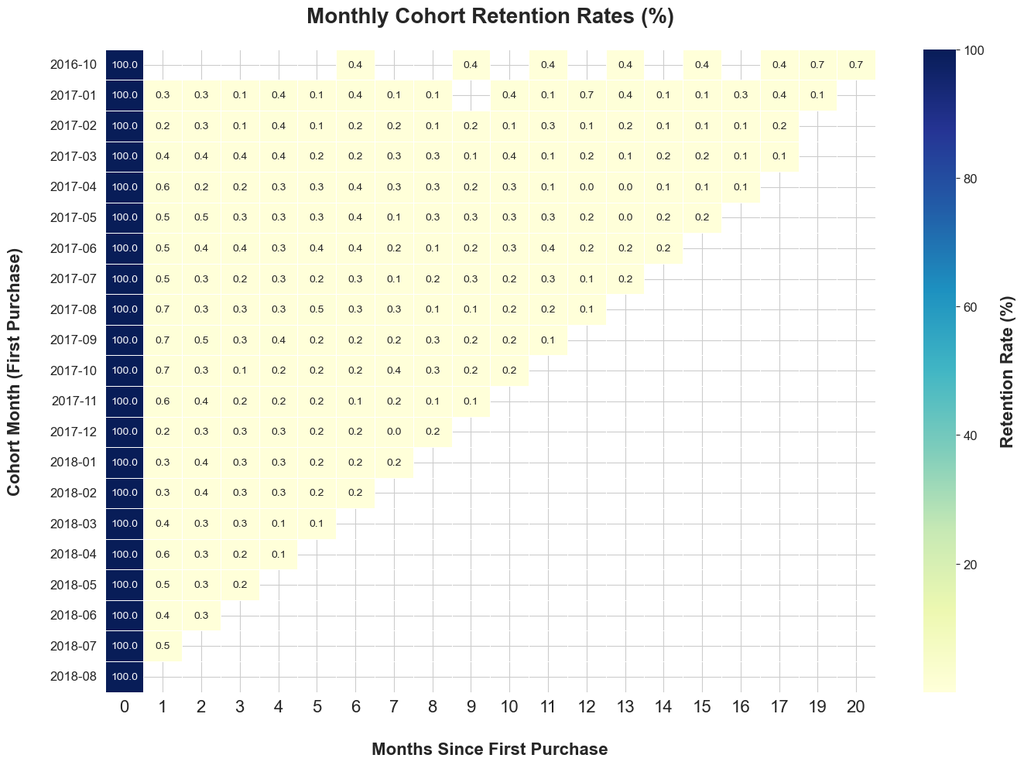

```
Cohort Retention Rates (%) - First 12 months:
```

| cohort_index cohort_month | 0 | 1 | 2 | 3 | 4 | 5 | 6 | 7 | 8 | 9 | 10 | 11 | 12 |
| --- | --- | --- | --- | --- | --- | --- | --- | --- | --- | --- | --- | --- | --- |
| 2016-09 | 100.0 | nan | nan | nan | nan | nan | nan | nan | nan | nan | nan | nan | nan |
| 2016-10 | 100.0 | nan | nan | nan | nan | nan | 0.4 | nan | nan | 0.4 | nan | 0.4 | nan |
| 2016-12 | 100.0 | 100.0 | nan | nan | nan | nan | nan | nan | nan | nan | nan | nan | nan |
| 2017-01 | 100.0 | 0.3 | 0.3 | 0.1 | 0.4 | 0.1 | 0.4 | 0.1 | 0.1 | nan | 0.4 | 0.1 | 0.7 |
| 2017-02 | 100.0 | 0.2 | 0.3 | 0.1 | 0.4 | 0.1 | 0.2 | 0.2 | 0.1 | 0.2 | 0.1 | 0.3 | 0.1 |
| 2017-03 | 100.0 | 0.4 | 0.4 | 0.4 | 0.4 | 0.2 | 0.2 | 0.3 | 0.3 | 0.1 | 0.4 | 0.1 | 0.2 |
| 2017-04 | 100.0 | 0.6 | 0.2 | 0.2 | 0.3 | 0.3 | 0.4 | 0.3 | 0.3 | 0.2 | 0.3 | 0.1 | 0.0 |
| 2017-05 | 100.0 | 0.5 | 0.5 | 0.3 | 0.3 | 0.3 | 0.4 | 0.1 | 0.3 | 0.3 | 0.3 | 0.3 | 0.2 |
| 2017-06 | 100.0 | 0.5 | 0.4 | 0.4 | 0.3 | 0.4 | 0.4 | 0.2 | 0.1 | 0.2 | 0.3 | 0.4 | 0.2 |
| 2017-07 | 100.0 | 0.5 | 0.3 | 0.2 | 0.3 | 0.2 | 0.3 | 0.1 | 0.2 | 0.3 | 0.2 | 0.3 | 0.1 |
| 2017-08 | 100.0 | 0.7 | 0.3 | 0.3 | 0.3 | 0.5 | 0.3 | 0.3 | 0.1 | 0.1 | 0.2 | 0.2 | 0.1 |
| 2017-09 | 100.0 | 0.7 | 0.5 | 0.3 | 0.4 | 0.2 | 0.2 | 0.2 | 0.3 | 0.2 | 0.2 | 0.1 | nan |
| 2017-10 | 100.0 | 0.7 | 0.3 | 0.1 | 0.2 | 0.2 | 0.2 | 0.4 | 0.3 | 0.2 | 0.2 | nan | nan |
| 2017-11 | 100.0 | 0.6 | 0.4 | 0.2 | 0.2 | 0.2 | 0.1 | 0.2 | 0.1 | 0.1 | nan | nan | nan |
| 2017-12 | 100.0 | 0.2 | 0.3 | 0.3 | 0.3 | 0.2 | 0.2 | 0.0 | 0.2 | nan | nan | nan | nan |
| 2018-01 | 100.0 | 0.3 | 0.4 | 0.3 | 0.3 | 0.2 | 0.2 | 0.2 | nan | nan | nan | nan | nan |
| 2018-02 | 100.0 | 0.3 | 0.4 | 0.3 | 0.3 | 0.2 | 0.2 | nan | nan | nan | nan | nan | nan |
| 2018-03 | 100.0 | 0.4 | 0.3 | 0.3 | 0.1 | 0.1 | nan | nan | nan | nan | nan | nan | nan |
| 2018-04 | 100.0 | 0.6 | 0.3 | 0.2 | 0.1 | nan | nan | nan | nan | nan | nan | nan | nan |
| 2018-05 | 100.0 | 0.5 | 0.3 | 0.2 | nan | nan | nan | nan | nan | nan | nan | nan | nan |
| 2018-06 | 100.0 | 0.4 | 0.3 | nan | nan | nan | nan | nan | nan | nan | nan | nan | nan |
| 2018-07 | 100.0 | 0.5 | nan | nan | nan | nan | nan | nan | nan | nan | nan | nan | nan |
| 2018-08 | 100.0 | nan | nan | nan | nan | nan | nan | nan | nan | nan | nan | nan | nan |

```python
# 7.2.1. Filter cohorts with at least 50 customers (a common threshold)
valid_cohorts = cohort_size[cohort_size >= 50].index
retention_matrix_filtered = retention_matrix.loc[valid_cohorts]

# Round for display
retention_matrix = retention_matrix.round(1)

# 7.2.2. Heatmap visualization
plt.figure(figsize=(14, 10))

sns.heatmap(
    retention_matrix_filtered,
    annot=True,
    fmt='.1f',
    cmap='YlGnBu',
    linewidths=0.5,
    cbar_kws={'label': 'Retention Rate (%)'}
)

# Get the current axes and colorbar
ax = plt.gca()
cbar = ax.collections[0].colorbar  # the colorbar object

# Make the colour bar label larger and bolder
cbar.set_label(
    'Retention Rate (%)',
    fontsize=16,
    fontweight='bold',
    labelpad=15
)

# make the percentage numbers/ticks on the colorbar larger
cbar.ax.tick_params(labelsize=12)   # controls the 0, 20, 40... numbers

plt.title('Monthly Cohort Retention Rates (%)', fontsize=20, fontweight='bold', pad=25)
plt.xlabel('Months Since First Purchase', fontsize=16, fontweight='bold' , labelpad=25)
plt.ylabel('Cohort Month (First Purchase)', fontsize=16, fontweight='bold' , labelpad=25)
plt.xticks(rotation=0, fontsize=16)
plt.yticks(rotation=0, fontsize=12)

plt.tight_layout()
plt.show()

# 7.2.3. Print retention table for reference (first 12 months)
print("Cohort Retention Rates (%) - First 12 months:")
display(retention_matrix.iloc[:, :13].style.format('{:.1f}'))
```

### 7.3. Insight sui Cohorts e Raccomandazioni di Retention

Il heatmap rivela tassi di riacquisto molto bassi, tipici di un marketplace come Olist con alto comportamento di acquirenti one-time.  
Riassumo i pattern chiave e propongo strategie actionable per migliorare la retention in tutti i cohorts.

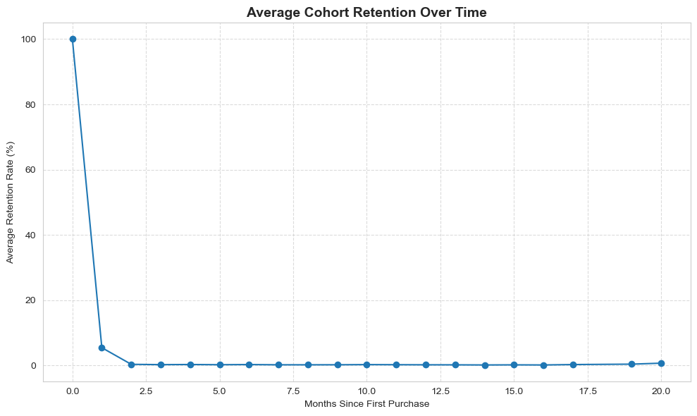

```python
# Average retention per month (across all cohorts)
avg_retention = retention_matrix.mean().dropna()  # ignore NaN in later months

plt.figure(figsize=(10, 6))
plt.plot(avg_retention.index, avg_retention.values, marker='o', color='#1f77b4')
plt.title('Average Cohort Retention Over Time', fontsize=14, fontweight='bold')
plt.xlabel('Months Since First Purchase')
plt.ylabel('Average Retention Rate (%)')
plt.grid(True, linestyle='--', alpha=0.7)
plt.tight_layout()
plt.show()
```

**Opportunità Complessiva**:  
Con tassi di ripetizione così bassi, anche un piccolo aumento nella frequenza (es. da 1.03 a 1.2 ordini medi per cliente) potrebbe aumentare i ricavi totali del 15–20 %.  
Concentrarsi sull'esperienza post-acquisto, offerte personalizzate e meccanismi di fedeltà per trasformare i compratori one-time in ricorrenti.

## 8. Previsione Base – Predizione dei Ricavi Futuri con Prophet

### 8.1. Previsione con Prophet

Utilizzo Facebook Prophet per prevedere i ricavi mensili futuri basati su trend storici e stagionalità.

Prophet è particolarmente adatto per dati di e-commerce con possibili pattern annuali (es. festività, domanda stagionale).

Per questa introduzione, mantengo il modello semplice (senza regressori esterni né festività personalizzate) per concentrarmi sulle capacità di base.

```python
# 8.1 & 8.2 Basic Forecasting with Prophet

# 8.1.1. Prepare time series data: monthly total revenue

# Use base_df (only delivered orders) for consistency
monthly_revenue = base_df[base_df['is_delivered']].copy()

# Group by month
monthly_revenue['ds'] = monthly_revenue['order_purchase_timestamp'].dt.to_period('M').dt.to_timestamp()

# Aggregate revenue per month
monthly_revenue = monthly_revenue.groupby('ds')['total_order_value'].sum().reset_index()

# Rename for Prophet (Prophet requires 'ds' (date) and 'y' (value))
monthly_revenue = monthly_revenue.rename(columns={'total_order_value': 'y'})

# Quick look at the data
print("Monthly revenue data shape:", monthly_revenue.shape)
print(monthly_revenue.head())

# 8.1.2. Create and fit model with logistic growth
model = Prophet(
    yearly_seasonality=True,
    weekly_seasonality=False,   # daily data not needed
    daily_seasonality=False,
    seasonality_mode='additive'  # better for revenue with growth
)

model.fit(monthly_revenue)

# 8.1.3. Create future dataframe and add the same cap/floor (forecast next 12 months)
future = model.make_future_dataframe(periods=12, freq='MS')  # MS = month start

# 8.1.4. Predict
forecast = model.predict(future)

# Clip any remaining negatives (extra safety at post-processing)
forecast['yhat'] = forecast['yhat'].clip(lower=0)
forecast['yhat_lower'] = forecast['yhat_lower'].clip(lower=0)
forecast['yhat_upper'] = forecast['yhat_upper'].clip(lower=0)

# 8.1.5. Plot forecast with Plotly (interactive)
fig = go.Figure()

# Uncertainty interval (two traces to create the shaded area)
fig.add_trace(go.Scatter(  # Upper bound (invisible line)
    x=forecast['ds'],
    y=forecast['yhat_upper'],
    mode='lines',
    line=dict(color='#27ae60', width=1, dash='dot'),
        name='Upper Uncertainty Bound'
))

fig.add_trace(go.Scatter(  # Lower bound + fill between upper & lower
    x=forecast['ds'],
    y=forecast['yhat_lower'],
    mode='lines',
    #fill='tonexty',         # fill area to the previous trace (upper bound)
    line=dict(color='#27ae60', width=1, dash='dot'),
    name='Lower Uncertainty Bound'
))

# Forecast
fig.add_trace(go.Scatter(      # Adds the forecast line
    x=forecast['ds'],
    y=forecast['yhat'],        # predicted values
    mode='lines',
    name='Forecast',
    line=dict(color='#ff7f0e', dash='dash', width=3.5) # orange + dashed
))

# Historical data
fig.add_trace(go.Scatter(      # Adds the historical line
    x=monthly_revenue['ds'],   # dates on x-axis
    y=monthly_revenue['y'],    # actual revenue values
    mode='lines+markers',      # line with dots at each point
    name='Historical Revenue', # legend label
    line=dict(color='#1f77b4', width=3.5) # blue color
))

# Final styling
fig.update_layout(
    title='<b>Monthly Revenue Forecast (Next 12 Months)</b>',
    title_x=0.5,
    title_font_size=18,
    xaxis_title='Date',
    yaxis_title='Total Revenue (BRL)',
    hovermode='x unified',  # shows all values when hovering on a date
    height=600,
    template='plotly_white' # clean white background
)

fig.show()

# 6. Print forecast for next 6 months
print("\nForecast for next 6 months:")
future_forecast = forecast[forecast['ds'] > monthly_revenue['ds'].max()][['ds', 'yhat', 'yhat_lower', 'yhat_upper']].head(6)
future_forecast['yhat'] = future_forecast['yhat'].round(2)
future_forecast['yhat_lower'] = future_forecast['yhat_lower'].round(2)
future_forecast['yhat_upper'] = future_forecast['yhat_upper'].round(2)
display(future_forecast)
```

```
16:29:19 - cmdstanpy - INFO - Chain [1] start processing
16:29:19 - cmdstanpy - INFO - Chain [1] done processing
```

```
Monthly revenue data shape: (23, 2)
          ds             y
0 2016-09-01      0.000000
1 2016-10-01  47271.200000
2 2016-12-01     19.620000
3 2017-01-01 127545.670000
4 2017-02-01 271298.650000
```

[interactive chart not shown]

```
Forecast for next 6 months:
```

|  | ds | yhat | yhat_lower | yhat_upper |
| --- | --- | --- | --- | --- |
| 23 | 2018-09-01 | 1589425.680000 | 1519977.880000 | 1666357.970000 |
| 24 | 2018-10-01 | 1553858.560000 | 1483368.020000 | 1633457.640000 |
| 25 | 2018-11-01 | 1279389.770000 | 1205482.610000 | 1352166.030000 |
| 26 | 2018-12-01 | 1578930.870000 | 1501889.590000 | 1650012.790000 |
| 27 | 2019-01-01 | 1829107.500000 | 1753655.530000 | 1898296.960000 |
| 28 | 2019-02-01 | 1397814.710000 | 1321736.580000 | 1473373.690000 |

**Nota**: La linea tratteggiata della previsione e i limiti di incertezza si estendono indietro sul periodo storico per mostrare l'adattamento del modello in-sample.  
La previsione futura effettiva inizia dopo l'ultimo punto dati storico (agosto 2018).

### 8.2. Insight di Previsione e Raccomandazioni di Business

L'adattamento sui dati storici è forte, supportando fiducia nelle proiezioni a breve termine. Di seguito i principali insight e strategie actionable.

**Insight Chiave:**

**Raccomandazioni Azionabili:**

1. **Pianificazione Inventario e Logistica**
   - Scalare lo stock per le categorie top (salute_bellezza, letto_bagno_tavola, orologi_regali) del 10–20 % sopra i livelli attuali per il 2019.
   - Prioritizzare capacità in SP, RJ, MG — stati ad alto revenue con possibili picchi stagionali.
2. **Marketing e Promozioni**
   - Aumentare budget in Q4 (Black Friday, Natale) e Q1 (vendite post-festive) — target bundle su articoli per la casa, bellezza e regali per capitalizzare la stagionalità rilevata.
   - Lanciare campagne focalizzate sulla retention (es. "Sconto sul Secondo Acquisto") all'inizio del 2019 per aumentare i tassi di ripetizione e superare la previsione.
3. **Gestione del Rischio**
   - Usare i limiti inferiori come obiettivi di budget conservativi.
   - Monitorare reale vs previsione mensilmente — se sotto il limite inferiore, indagare churn (collegare al segmento "Lost / Hibernating" di RFM) o fattori esterni.
4. **Sinergia con Retention**
   - Combinare con cohort/RFM: focalizzarsi su "Recent High-Value New" e "At Risk" — un lift del 2–3 % nella retention mese 1 potrebbe spingere i ricavi 2019 del 15–20 % sopra il baseline previsto.

**Opportunità Complessiva**:

Il modello proietta una crescita solida assumendo che le tendenze attuali continuino.

## 9. Finalizzazione e Presentazione

### 9.1. Esportazione delle Tabelle Chiave

Tutte le tabelle processate vengono salvate in `./data/processed/` per un facile import in Power BI o altri tool.

Questo garantisce riproducibilità e abilita dashboard interattivi (ad esempio, ricavi per stato/categoria, segmenti RFM, retention dei cohorts, trend di previsione).

```python
# 9.1 Exporting Key Tables

processed_dir = './data/processed/'
os.makedirs(processed_dir, exist_ok=True)

# 9.1.1. Cleaned orders with features
orders.to_csv(processed_dir + 'cleaned_orders_with_features.csv', index=False)

# 9.1.2. Base working table (orders + customers + payments)
base_df.to_csv(processed_dir + 'base_working_table.csv', index=False)

# 9.1.3. State performance summary
state_summary.to_csv(processed_dir + 'state_performance_summary.csv', index=False)

# 9.1.4. Category performance
category_performance.to_csv(processed_dir + 'category_performance.csv', index=False)

# 9.1.5. State-category breakdown
state_category_summary.to_csv(processed_dir + 'state_category_summary.csv', index=False)

# 9.1.6. RFM customers with scores & segments
rfm.to_csv(processed_dir + 'rfm_customers_with_segments.csv', index=False)

# 9.1.7. RFM segment summary
segment_summary.to_csv(processed_dir + 'rfm_segment_summary.csv', index=False)

# 9.1.8. Cohort retention matrix
retention_matrix.to_csv(processed_dir + 'cohort_retention_matrix.csv')

# 9.1.9. Monthly revenue + forecast
monthly_revenue.to_csv(processed_dir + 'monthly_historical_revenue.csv', index=False)
forecast.to_csv(processed_dir + 'monthly_revenue_forecast.csv', index=False)

print("All key tables exported successfully to:")
print(processed_dir)
print("Ready for Power BI import!")
```

```
All key tables exported successfully to:
./data/processed/
Ready for Power BI import!
```

### 9.2. Riassunto del Progetto e Insight Chiave

Questo progetto dimostra competenze di analisi dati end-to-end: dai dati raw alle raccomandazioni di business, con forti capacità in Python/SQL/visualizzazione.

### 9.3. Dashboard in Power BI

Per rendere l'analisi più interattiva e pronta per l'uso business, ho creato un dashboard in Power BI utilizzando le tabelle esportate dalla cartella processed.

**Caratteristiche Principali del Dashboard:**

**Pagina Overview ("Olist Overview")**

Riassunto di alto livello con KPI globali e visual chiave:

- Card semplici per metriche core: Ricavi Totali, Clienti Unici Totali, % Share Ricavi, % Share Clienti, Spesa Media per Cliente, Acquisti Medi per Cliente.
- Grafico a linee: Ricavi Storici + Previsione 12 Mesi
- Matrice/Heatmap: Retention dei Cohorts (Mesi dalla prima acquisto)
- Grafico a barre raggruppate: % Share Ricavi vs % Share Clienti per Segmento RFM
- Mappa Bubble: Ricavi per Stato Brasiliano
- Grafico a barre orizzontali: Top 10 Categorie per Ricavi

Nessun slicer su questa pagina per mantenerla come snapshot globale pulito.

**Pagina Customer Deep Dive**

Focalizzata su analisi dettagliata dei clienti con interattività:

- Scatter Plot RFM: Recency vs Monetary (dimensione per Frequency, colore per Segmento)
- Tabella dinamica clienti: Filtrata e ordinata per segmento selezionato (monetary decrescente)
- Card semplici e Gauges per KPI specifici per segmento (es. % Repeat Customers, Spesa Media, ecc.)
- Multipli slicer: Segmento RFM, Range Recency, Range Frequency, Range Monetary — per filtraggio profondo e esplorazione di gruppi clienti.

**Screenshots:**

*Pagina Olist Overview:*

[figure not shown]

*Pagina Customer Deep Dive:*

[figure not shown]

**Link al Dashboard**:  
[Power BI Service – Olist Analytics Dashboard](https://app.powerbi.com/view?r=eyJrIjoiNTFjYTAyYTctYTU0YS00ZWIzLTljZTEtMDQ0MjA4MzljODI3IiwidCI6IjZiNTQyOWEzLTM3MjItNDA3Yy04NmQyLWY4MGViNjEwMjU4MSIsImMiOjR9)

Il dashboard è pubblicato su Power BI Service (account personale gratuito) e può essere condiviso via link per visualizzazione interattiva.

### 9.4. Conclusione del Progetto e Prossimi Passi

**Riassunto dei Risultati:**

- Caricato e pulito il dataset di E-Commerce Brasiliano Olist (~100k ordini, 9 tabelle).
- Eseguito EDA profondo: vendite per stato/categoria, preferenze regionali, performance di consegna.
- Consegnata segmentazione RFM con gruppi clienti actionable e raccomandazioni.
- Analizzata retention dei cohorts → evidenziate tassi di ripetizione molto bassi e strategie di miglioramento.
- Previsione dei ricavi futuri con Prophet → identificati trend di crescita e opportunità stagionali.
- Creati visual interattivi (Plotly) e esportate tabelle per dashboarding.

**Lezioni Chiave Apprese:**

- Transizione riuscita da R a Python: pandas per manipolazione dati, Prophet per forecasting, Plotly per visual interattivi.
- Realtà dell'e-commerce: tasso di riacquisto molto basso (~3 %), alta dipendenza da compratori one-time.
- Importanza del contesto business: ogni analisi ha portato a raccomandazioni concrete.
- Peculiarità di Power BI: relazioni e slicer necessitano setup attento per cross-filtering.

**Miglioramenti Futuri e Idee:**

- Incorporare dati esterni (es. festività brasiliane, indicatori economici) per forecasting più ricco.
- Esplorare impatto dei metodi di pagamento su segmenti e retention (boleto vs carta vs rate).
- Eseguire A/B test reali su tattiche di retention (es. email win-back, sconti) se dati live disponibili.
- Scalare a modelli più avanzati (es. deep learning per serie temporali, ML per customer lifetime value).

Questo progetto dimostra competenze di analisi dati end-to-end: dai dati raw alle raccomandazioni di business, con forti capacità in Python/SQL/visualizzazione.

Grazie per avermi seguito!

### 9.5 Report Pubblicato e Download

L'analisi interattiva completa è disponibile online sul mio sito web personale:

**[Visualizza Report Interattivo (HTML)](https://emilionahuelpattini.com/it/data/data-analysis/projects/olist-report/olist-ecommerce-analysis.html)**  
(Raccomandato – interattività completa, TOC cliccabile, celle codice espandibili, grafici Plotly)

**Scarica Versione PDF**:  
[Report Olist Analytics – PDF](https://emilionahuelpattini.com/it/data/data-analysis/projects/olist-report/olist-ecommerce-analysis.pdf)  
(Export statico per lettura offline o stampa – generato dal notebook)

Entrambe le versioni si basano sullo stesso codice sorgente del Jupyter notebook disponibile nel mio repository.

Emilio Nahuel Pattini – Buenos Aires, 1 febbraio 2026